# My assignment for reproducible research

This assignment makes use of data from a personal activity monitoring device. This device collects data at 5 minute intervals through out the day. The data consists of two months of data from an anonymous individual collected during the months of October and November, 2012 and include the number of steps taken in 5 minute intervals each day.

# Loading the data

First, we fetch the dataset from the web and load it into our R environment.

```r
directory <- "figure"

if(!file.exists(directory)) {
        dir.create(directory)
}

setwd(directory)
dir()
```

```
## [1] "activity.csv"      "activity.zip"      "PA1_template.docx"
## [4] "plot1.png"         "plot2.png"         "plot3.png"
## [7] "plot4.png"
```

```r
url <- "https://d396qusza40orc.cloudfront.net/repdata%2Fdata%2Factivity.zip"

# Keep track of download date
download.file(url, "activity.zip")
#date.download <- date()

# Unzip the file and read it
name.file <- unzip(zipfile = "activity.zip", list = TRUE)$Name
unzip(zipfile = "activity.zip", name.file)
df <- read.csv(name.file, colClasses = c("integer", "Date", "integer"))
```

```r
dim(df)
```

```
## [1] 17568     3
```

Our dataset contains 17.568 rows and 3 columns. Once data are loaded we are interested in getting a general overview of the data.

# Observing the data

## General overview

```r
summary(df)
```

```
##      steps             date               interval
##  Min.   :  0.00   Min.   :2012-10-01   Min.   :   0.0
##  1st Qu.:  0.00   1st Qu.:2012-10-16   1st Qu.: 588.8
##  Median :  0.00   Median :2012-10-31   Median :1177.5
##  Mean   : 37.38   Mean   :2012-10-31   Mean   :1177.5
##  3rd Qu.: 12.00   3rd Qu.:2012-11-15   3rd Qu.:1766.2
##  Max.   :806.00   Max.   :2012-11-30   Max.   :2355.0
##  NA's   :2304
```

We have here 2 month of monitoring data from 2012-10-01 to 2012-11-30. The steps variable contains NA values.

## Activity overview

We want to observe the total number of steps taken each day by the user and out of this extract the mean and the median.

First, we plot an histogram with the number of steps per day.

```r
library(dplyr)
```

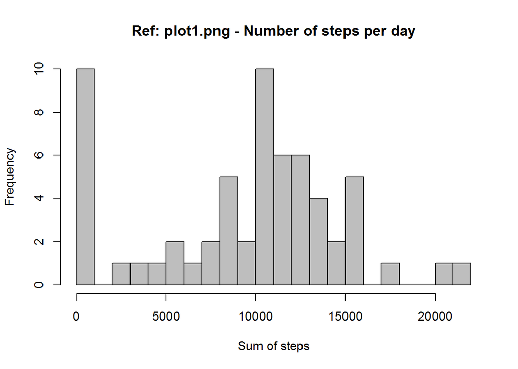

```r
# Sum the number of steps per day
sum.df <- df %>%
        group_by(date) %>%
        summarise(sum.steps = sum(steps, na.rm = TRUE))

# Plot the distribution for report
hist(sum.df$sum.steps, breaks = 20, col = "grey", main = "Ref: plot1.png - Number of steps per day", xlab = "Sum of steps")
```

The sample distribution seems to be bimodal with one pic at 0 and one pic at about 10000 steps. Furthermore, we can identify that there are some outliers. Then we extract the mean and the median from the distribution.

```r
# Calculating the median and mean for the sum of steps made each day by the user
median.df <- with(sum.df, median(sum.steps))
mean.df <- with(sum.df, mean(sum.steps))

# Printing out
median.df
```

```
## [1] 10395
```

```r
mean.df
```

```
## [1] 9354.23
```

Mean < Median meaning that the distribution is left skewed (as we could see in the histogram) which is certainly due to the high number of outliers with a number of steps equal to 0.

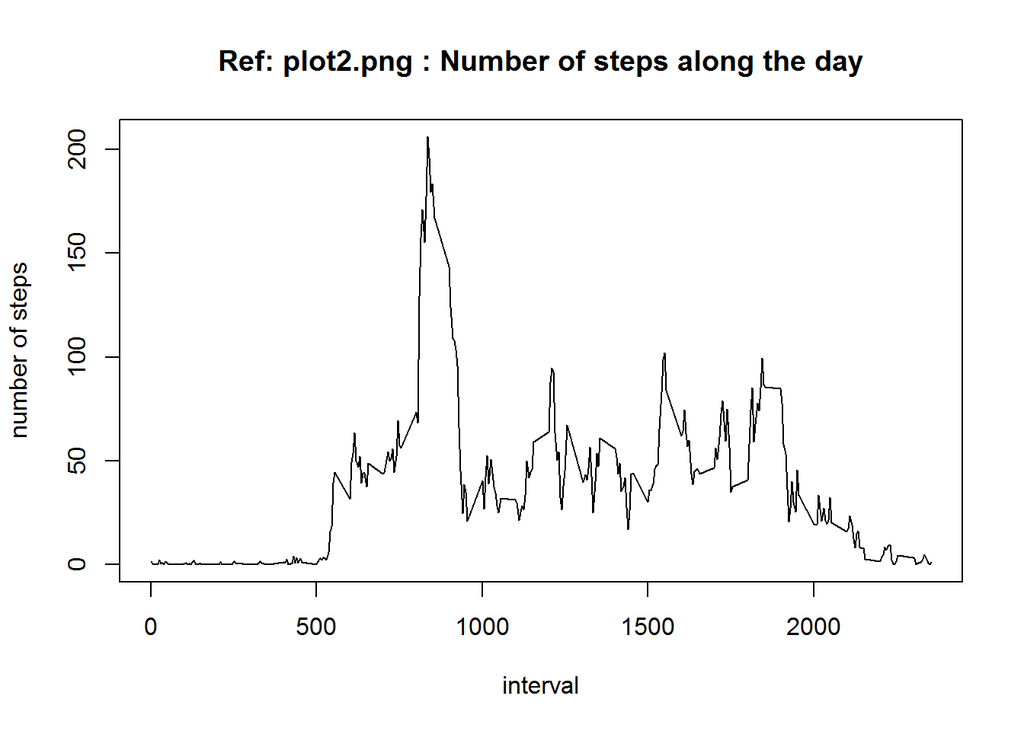

```r
library(dplyr)
# stack each day and calculate the mean for each interval
ts.df <- df %>%
        group_by(interval) %>%
        summarise(mean.steps = mean(steps, na.rm = TRUE))

plot(x = ts.df$interval, y = ts.df$mean.steps, xlab = "interval", ylab = "number of steps", type = 'l', main = "Ref: plot2.png : Number of steps along the day")
```

```r
#Calculating the max number of steps
ts.df.max <- ts.df[which(ts.df$mean.steps == max(ts.df$mean.steps)),]
ts.df.max
```

```
## # A tibble: 1 × 2
##   interval mean.steps
##      <int>      <dbl>
## 1      835   206.1698
```

The maximun averaged number of steps per day is obtained for the interval 830 to 835.

## Imputing missing values

When we looked at the summary, we saw that some values were missing.

```r
# summarise missing values
any(is.na(df))
```

```
## [1] TRUE
```

```r
colSums(is.na(df))
```

```
##    steps     date interval
##     2304        0        0
```

We want to see when those NAs appear by plotting the sum of NAs over time.

```r
library(lubridate)
```

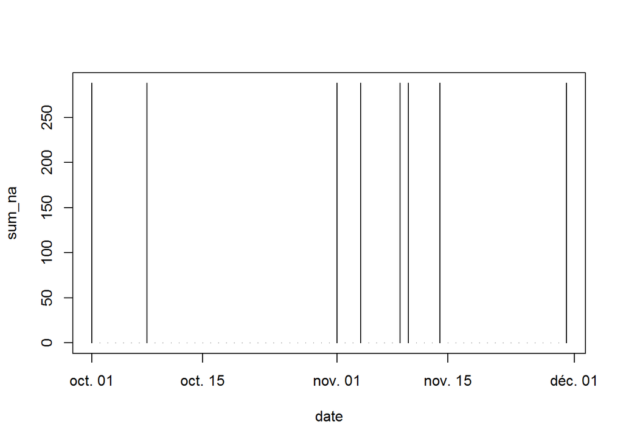

```r
library(dplyr)

# Summarizing the sum of NAs for the steps variable
nas <- df %>%
        group_by(date) %>%
        summarise(sum_na = sum(is.na(steps)))

with(nas, plot(date, sum_na, type = "h"))
```

NA’s don’t seem to be generated over a particular pattern. Missing values appear toguether and seem to correspond to an entire day. We do a confirmation by printing the number of steps over time.

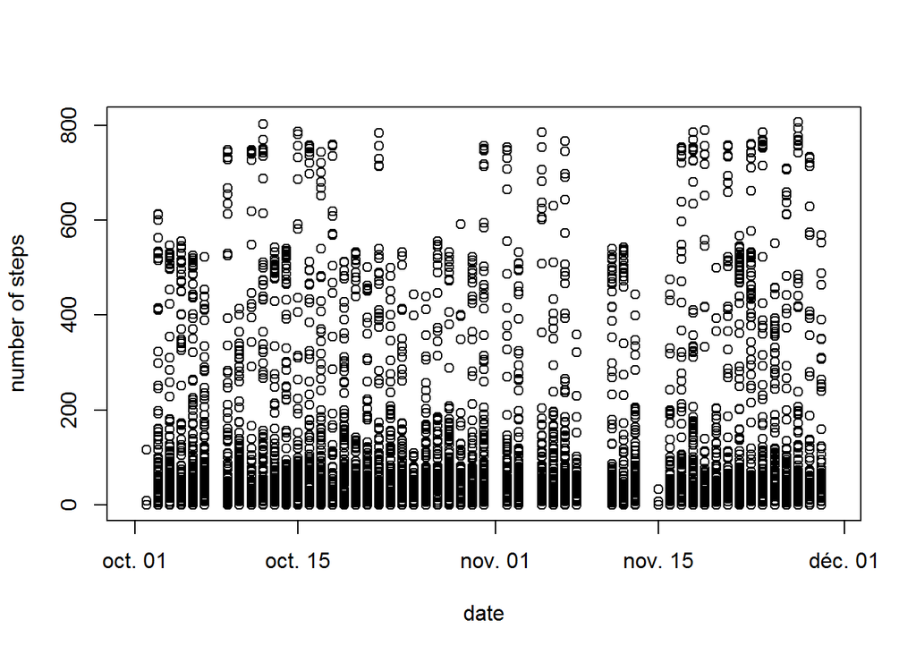

```r
plot(x = df$date, y = df$steps, xlab = "date", ylab = "number of steps")
```

As we can see some days aren’t monitored at all and some others only have a few values. Nevertheless it doesn’t seem to be due to a seasonality pattern within the data. It seems to appear randomly.

Since the variable is continuous, we keep track of where missing values appeared in the dataset by adding a logical column.

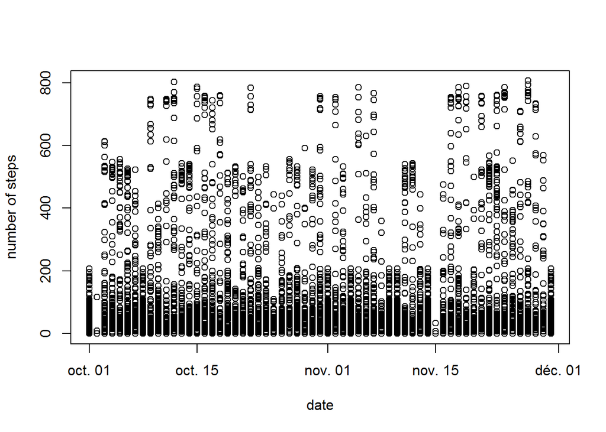

```r
library(dplyr)

# Add a column containing information about the presence of missing values
df$was.missing <- is.na(df$steps)

# Replace NA values by the mean
impute.mean <- function(x) {
        replace(x, is.na(x), mean(x, na.rm = TRUE))
}

# replace each missing value by the mean observed for the same interval
df.imputed <- df %>%
    group_by(interval) %>%
    mutate(
        steps = impute.mean(steps)
    )

plot(x = df.imputed$date, y = df.imputed$steps, xlab = "date", ylab = "number of steps")
```

We confirm that missing days are filled in and so that missing values have been imputed.

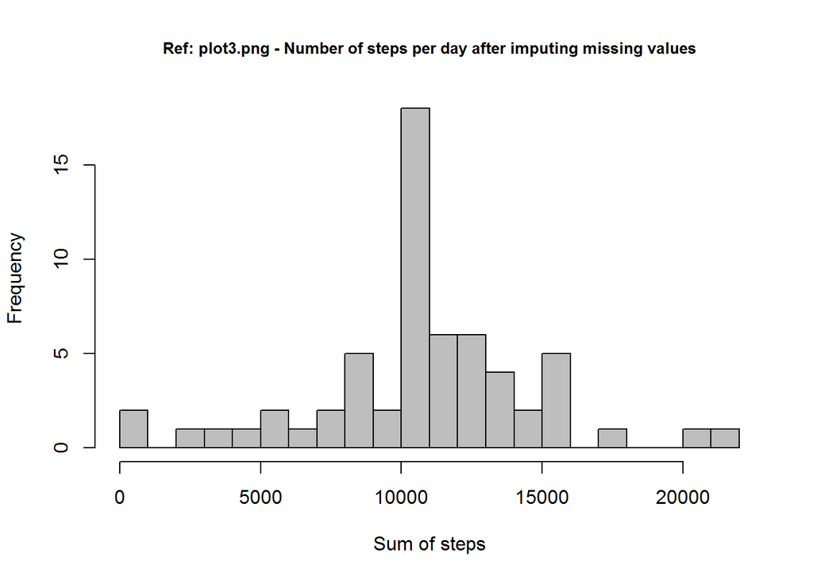

```r
library(dplyr)

# Summarizing and plotting the sum of steps per days
sum.df.imputed <- df.imputed %>%
        group_by(date) %>%
        summarise(sum.steps = sum(steps, na.rm = TRUE))

hist(sum.df.imputed$sum.steps, breaks = 20, col = "grey", main = "Ref: plot3.png - Number of steps per day after imputing missing values", cex.main=0.8, xlab = "Sum of steps")
```

As expected, the number of values at 0 drops and individuals move towards the center of mass of the histogram. We confirm this information by calculating the mean and median of the distribution.

```r
# Calculating the median and mean for the sum of steps made each day by the user
median.df.imputed <- with(sum.df.imputed, median(sum.steps))
mean.df.imputed <- with(sum.df.imputed, mean(sum.steps))

# Printing out
median.df.imputed
```

```
## [1] 10766.19
```

```r
mean.df.imputed
```

```
## [1] 10766.19
```

Imputing missing values with the mean centers the distribution. Now the median and the mean are equal so that the individuals are equally distributed.

## Seasonality analysis

In this part, we want to see whether there is a difference in activity between weekdays and the weekends.

```r
# Add information on the day of week
df.imputed$day.of.week <- weekdays(df.imputed$date)
df.imputed$is.weekend <- with(df.imputed, as.factor(ifelse(day.of.week == "samedi" | day.of.week == "dimanche", "weekend", "weekday")))
```

Then, we want to observe whether users walk more over weekends or not

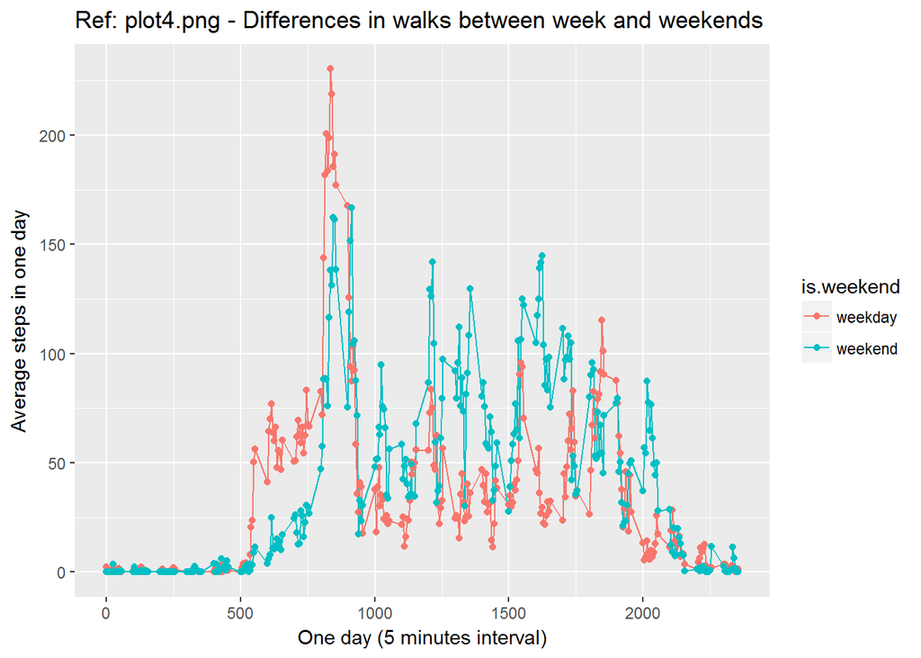

```r
library(ggplot2)
library(dplyr)

# Summarizing the average number of steps
ts.df.imputed <- df.imputed %>%
        group_by(is.weekend, interval) %>%
        summarise(mean.steps = mean(steps, na.rm = TRUE))

# Plotting the number of steps along the days depending on the nature of the week's days (week or weekends)
ggplot(ts.df.imputed, aes(x = interval, y = mean.steps, group = is.weekend, colour = is.weekend)) +
        geom_line() +
        geom_point() +
        ylab("Average steps in one day") +
        xlab("One day (5 minutes interval)") +
        ggtitle("Ref: plot4.png - Differences in walks between week and weekends")
```